# Differences in Physicians' Verbal and Nonverbal Communication With Black and White Patients at the End of Life - ScienceDirect

- [View **PDF**](https://www-sciencedirect-com.ezproxy.spu.edu/science/article/pii/S0885392415004029/pdfft?md5=bf33e341747de8973f9d1096bc7282f8&pid=1-s2.0-S0885392415004029-main.pdf)

## Outline

1. Abstract
2. Key Words
3. Introduction
4. Methods
5. Results
6. Discussion
7. Disclosures and Acknowledgments
8. References

## Cited By (58)

## Figures (2)

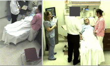

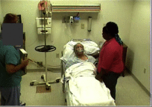

## Tables (4)

1. Table 1
2. Table 2
3. Table 3
4. Table 4

## [Journal of Pain and Symptom Management](https://www-sciencedirect-com.ezproxy.spu.edu/journal/journal-of-pain-and-symptom-management)

[Volume 51, Issue 1](https://www-sciencedirect-com.ezproxy.spu.edu/journal/journal-of-pain-and-symptom-management/vol/51/issue/1), January 2016, Pages 1-8

# Original Article Differences in Physicians' Verbal and Nonverbal Communication With Black and White Patients at the End of Life

[Andrea M.ElliottMD<sup>a</sup>](https://www-sciencedirect-com.ezproxy.spu.edu/science/article/pii/S0885392415004029?via%3Dihub#!)[Stewart C.AlexanderPhD<sup>e</sup>](https://www-sciencedirect-com.ezproxy.spu.edu/science/article/pii/S0885392415004029?via%3Dihub#!)[Craig A.MescherMD<sup>a</sup>](https://www-sciencedirect-com.ezproxy.spu.edu/science/article/pii/S0885392415004029?via%3Dihub#!)[DeepikaMohanMD, MPH<sup>b</sup>](https://www-sciencedirect-com.ezproxy.spu.edu/science/article/pii/S0885392415004029?via%3Dihub#!)[Amber E.BarnatoMD, MPH, MS<sup>a</sup><sup>c</sup><sup>d</sup>](https://www-sciencedirect-com.ezproxy.spu.edu/science/article/pii/S0885392415004029?via%3Dihub#!)

[https://doi.org/10.1016/j.jpainsymman.2015.07.008](https://doi-org.ezproxy.spu.edu/10.1016/j.jpainsymman.2015.07.008)[Get rights and content](https://s100.copyright.com/AppDispatchServlet?publisherName=ELS&contentID=S0885392415004029&orderBeanReset=true)

Under an Elsevier [user license](https://www-elsevier-com.ezproxy.spu.edu/open-access/userlicense/1.0/)

Open archive

## Abstract

### Context

Black patients are more likely than white patients to die in the [intensive care unit](https://www-sciencedirect-com.ezproxy.spu.edu/topics/nursing-and-health-professions/intensive-care-unit) with life-sustaining treatments. Differences in patient- and/or surrogate-provider communication may contribute to this phenomenon.

### Objectives

To test whether hospital-based physicians use different verbal and/or nonverbal communication with black and white simulated patients and their surrogates.

### Methods

We conducted a randomized factorial trial of the relationship between patient race and physician communication using high-fidelity simulation. Using a combination of probabilistic and convenience sampling, we recruited 33 hospital-based physicians in western Pennsylvania who completed two encounters with prognostically similar, critically and terminally ill black and white elders with identical treatment preferences. We then conducted detailed content analysis of audio and video recordings of the encounters, coding verbal emotion-handling and shared decision-making behaviors, and [nonverbal behaviors](https://www-sciencedirect-com.ezproxy.spu.edu/topics/neuroscience/nonverbal-behavior) (time interacting with the patient and/or surrogate, with open vs. closed posture, and touching the patient and physical proximity). We used a paired *t*-test to compare each subjects' summed verbal and nonverbal communication scores with the black patient compared to the white patient.

### Results

Subject physicians' verbal communication scores did not differ by patient race (black vs. white: 8.4 vs. 8.4, *P*-value = 0.958). However, their nonverbal communication scores were significantly lower with the black patient than with the white patient (black vs. white: 2.7 vs. 2.9, *P*-value 0.014).

### Conclusion

In this small regional sample, hospital-based physicians have similar verbal communication behaviors when discussing end-of-life care for otherwise similar black and white patients but exhibit significantly fewer positive, rapport-building nonverbal cues with black patients.

## Key Words

Communication

race

terminal care

provider behavior

disparities

## Introduction

One in five people die with [intensive care unit](https://www-sciencedirect-com.ezproxy.spu.edu/topics/nursing-and-health-professions/intensive-care-unit) (ICU) services,<sup>1</sup> yet most people have preferences against dying in the hospital with aggressive, life-prolonging treatment.2, 3, 4 End-of-life ICU and life-sustaining treatment use (e.g., [mechanical ventilation](https://www-sciencedirect-com.ezproxy.spu.edu/topics/medicine-and-dentistry/artificial-respiration), feeding tubes, and hemodialysis) varies by race, with blacks being more likely than whites to die in ICU with life-sustaining treatments.4, 5, 6, 7, 8, 9 This is contrary to the well-documented phenomenon of black patients being less likely than whites to receive preventive and early curative treatments.10, 11, 12, 13, 14, 15

Commentators advance several hypotheses to explain greater end-of-life treatment intensity among black patients, including inferior patient-doctor communication.16, 17, 18 Black patients report worse communication with their physicians,19, 20, 21, 22, 23, 24, 25, 26, 27, 28, 29, 30, 31, 32, 33, 34, 35, 36, 37 which in turn impacts trust,20, 22, 23, 24, 25, 26, 27 adherence,26, 27, 28, 29 disease outcomes,29, 30, 31, 32, 33, 34, 35, 36 and mortality.<sup>37</sup> Communication is not just the spoken word (verbal communication), but also involves nonverbal cues such as eye contact, body positioning, and touch (nonverbal communication). Nonverbal communication influences interpretation of verbal messages,<sup>38</sup> is linked to rapport, patient trust, satisfaction, recall, compliance, symptom resolution, long-term health improvements, and understanding of high-intensity medical scenarios.39, 40, 41, 42, 43, 44, 45

Implicit bias, also known as implicit [social cognition](https://www-sciencedirect-com.ezproxy.spu.edu/topics/medicine-and-dentistry/social-cognition), refers to attitudes or stereotypes that affect our understanding, actions, and decisions unconsciously. In the nonmedical setting, studies demonstrate that blacks experience such bias through nonverbal communication during their interactions with whites.46, 47, 48 Little is known about how nonverbal communication by physicians might influence patients' treatment preferences at the end of life. In a recent experiment using high-fidelity simulation, we found that hospital-based physicians made similar ICU admission and intubation decisions for otherwise similar black and white patients with end-stage cancer and life-threatening hypoxia, yet held exaggerated beliefs regarding blacks' preference for ICU and life-prolonging treatment.<sup>17</sup> We hypothesize that these beliefs may manifest as differences in communication behaviors when discussing prognosis and treatment with black compared to white patients. The purpose of the present study was to test whether hospital-based physicians use different verbal and/or nonverbal communication behaviors when they interact with black and white simulated patients and their surrogates.

## Methods

Details of the simulation study have been published previously.17, 49 Briefly, we conducted a randomized factorial trial to evaluate the relationship between patient race, embodied by the skin color of a patient, and physician decision-making and communication behaviors using high-fidelity simulation. Subject physicians completed two encounters with prognostically similar, critically and terminally ill black and white elders with identical treatment preferences, accompanied by a family member. We used block [random allocation](https://www-sciencedirect-com.ezproxy.spu.edu/topics/nursing-and-health-professions/randomization) to counterbalance encounter order, case (metastatic gastric cancer vs. metastatic pancreatic cancer), and patient race (black vs. white). A distracting survey, collecting demographic, training, and risk perception data, separated the encounters.

### Subjects and Recruitment

We recruited 33 hospital-based attending emergency medicine physicians, hospitalists or [intensivists](https://www-sciencedirect-com.ezproxy.spu.edu/topics/medicine-and-dentistry/intensivist) from Allegheny County, Pennsylvania, using a combination of probability sampling and convenience sampling.<sup>50</sup> Eligibility criteria included a minimum of one month of hospital-based clinical service per year.

### Communication Behavior Coding

We audio and video recorded each encounter using a handheld digital audio recorder and two wall-mounted cameras in each simulation room (Fig. 1). We used a previously validated verbal communication content coding scheme to code encounter audio for emotion handling and [shared decision making](https://www-sciencedirect-com.ezproxy.spu.edu/topics/nursing-and-health-professions/shared-decision-making) behaviors.51, 52 Providers received 1 point or 0 points for the presence or absence of a positive communication behavior (Table 2).

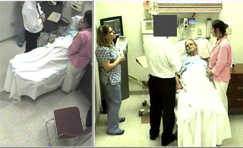

Fig. 1. Images used to code nonverbal communication behaviors. This illustrates the angles of the two cameras in each simulation room. The left panel shows the camera mounted on the wall behind the surrogate to the left of the patient. The right panel shows a view from a camera mounted on the wall across from the foot of the patient's bed.

We developed a novel nonverbal communication coding scheme to code the encounter videos. To create this scheme, we first drew on published literature to identify and adapt key constructs.53, 54, 55 Specifically, behaviors such as open body position, eye contact, proximity, and touch express positive constructs that underlie patient-doctor rapport, such as “involvement, availability, attention, warmth, encouragement, respect, understanding, empathy, and affiliation.”41, 55, 56, 57, 58, 59 Two team members (A. M. E. and A. E. B.) operationalized these constructs into independently verifiable nonverbal communication behaviors, adjusted for the length of the encounter (which varied from 3 minutes 40 seconds to 20 minutes and 13 seconds). Measures included 1) percent time spent with open body language; 2) percent time interacting with patient or surrogate (vs. with the chart, the monitor, or the nurse); 3) percent time touching the patient not for diagnostic purposes; and 4) distance from the patient in two planes: along the axis of the patient's body (e.g., distance from the head of bed, with the chest being the most proximate possible) and along the axis perpendicular to the patient's body (e.g., from the right handrail or lateral most plane of the patient's body, with sitting on or touching the bed being the most proximate possible). To measure behaviors 1–3, we used a stopwatch to time portions of the encounter during which the physician subject demonstrated a behavior. We then summed the time demonstrating the behavior and divided by the total encounter time to arrive at a measure of proportion of the encounter time, ranging from 0 (none) to 1 (100% of the time). To measure distance from the patient, we used context clues to assess distance from the head of bed (i.e., the patient's hip, knee, and foot) and from the side of the body (i.e., 12" × 12" floor tiles). We assessed distance beginning at approximately 30 seconds into the encounter to allow the physician to establish his/her position in the room. We then assigned points from 0 to 1 for least to greatest proximity. We illustrate these measures using annotated screen shots in Fig. 2. To ensure the robustness of nonverbal coding definitions, two coders independently coded 20% of the videos.

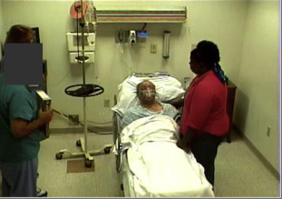

Fig. 2. Illustration of several measures of nonverbal communication. The physician to the left is standing >12" from the patient body's lateral most plane (each tile 12"), is standing at the knee while the actor/wife of the patient is at the chest (evident by the arm rail and patient's posture/flexion at the hip) and touching the bed. The physician is using closed body language (chart in front of body between himself and the patient) and is looking at the patient (although this information is obscured by the de-identifying box over the subject's face).

### Statistical Analyses

We used a [kappa statistic](https://www-sciencedirect-com.ezproxy.spu.edu/topics/medicine-and-dentistry/kappa-statistics) to assess inter-rater reliability for the verbal codes and concordance [correlation coefficients](https://www-sciencedirect-com.ezproxy.spu.edu/topics/nursing-and-health-professions/correlation-coefficient) to assess inter-rater reliability of the nonverbal codes. We summed the verbal communication behaviors to calculate a verbal communication score and summed the nonverbal communication behaviors to calculate a nonverbal communication score for each physician subject's encounter (one with a white patient and one with a black patient). We then used a paired *t*-test to compare each physician's scores for the black patient compared to the white patient. We also used an alternate nonparametric [rank sum test](https://www-sciencedirect-com.ezproxy.spu.edu/topics/medicine-and-dentistry/rank-sum-test) to assess the black-white score difference.

### Human Subjects

The University of Pittsburgh Institutional Review Board reviewed and approved the protocol, which concealed the purpose of the study from participants (e.g., to study variation in provider behavior by patient race). Subjects completed written [informed consent](https://www-sciencedirect-com.ezproxy.spu.edu/topics/medicine-and-dentistry/informed-consent), received $200 for their two hour participation, and received debriefing about the actual purpose of the study after completion.

## Results

### Baseline Characteristics

As previously reported, 33 hospital-based physicians completed the simulation study.<sup>50</sup> We excluded one subject's data from analysis because of actor response error during the simulation. The remaining 32 had technically complete video data for nonverbal communication coding but only 27 had technically complete audio data for verbal coding. We report the characteristics of 27 physicians with verbal scores and the 32 physicians with nonverbal scores in Table 1.

Table 1. Physician Characteristics

| Characteristic | Complete Audio Data (*n* = 27) | Complete Video Data (*n* = 32) |
| --- | --- | --- |
| Age | 41.7 (10.6) | 42.2 (10) |
| Male | 23 (85%) | 27 (84%) |
| Female | 4 (15%) | 5 (16%) |
| White | 15 (56%) | 18 (56%) |
| Black | 2 (7.4%) | 2 (6.3%) |
| Asian | 7 (26%) | 9 (28%) |
| Hispanic | 2 (7.4%) | 2 (6.3%) |
| Declined race*<sup>a</sup>* | 1 (3.7%) | 1 (3.1%) |
| Emergency physician | 11 (41%) | 12 (38%) |
| Hospitalist | 6 (22%) | 7 (22%) |
| Intensivist | 10 (37%) | 13 (41%) |
| Major teaching*<sup>b</sup>* | 17 (63%) | 21 (66%) |
| Minor teaching*<sup>c</sup>* | 10 (37%) | 11 (34%) |
| Hospital time*<sup>d</sup>* | 8.2 (3.5) | 7.9 (3.6) |
| Years since graduating*<sup>e</sup>* | 15.3 (10.2) | 16 (9.9) |

**a**

Physician declined to report race.

**b**

Primary position is in a major teaching hospital.

**c**

Primary position is in a minor teaching hospital.

**d**

Months the physician reports working in the hospital annually.

**e**

Years since the physician reported graduating medical school.

### Communication Behaviors

Table 2. Verbal Communication Behaviors (*n* = 54 Audiorecorded Encounters by 27 Physicians)

| Behavior | Point System*<sup>a</sup>* | Kappa | *n/N* (%) |
| --- | --- | --- | --- |
| Emotion-handling behaviors |  |  |  |
| Names an emotion | 1 Point if present | 0.67 | 2/54 (3.7%) |
| Expresses understanding for emotion | 1 Point if present | 0.61 | 3/54 (5.6%) |
| Shows respect for emotion | 1 Point if present | 1 | 0/54 (0%) |
| Supports emotion | 1 Point if present | 1 | 1/54 (1.9%) |
| Explores emotion | 1 Point if present | 0.66 | 0/54 (0%) |
| Use “I wish” statement | 1 Point if present | 1 | 0/54 (0%) |
| End-of-life communication and decision-making behaviors |  |  |  |
| Explains purpose of the visit | 1 Point if present | 0.83 | 18/54 (33%) |
| Asks what patient and surrogate know about the cancer | 1 Point if present | 1 | 11/54 (20%) |
| Asks what the patient and surrogate know about the current respiratory condition | 1 Point if present | 1 | 4/54 (7.4%) |
| Asks how much they want to know about their situation | 1 Point if present | 0.75 | 0/54 (0%) |
| Prepares patient and surrogate for a discussion of “bad news” | 1 Point if present | 0.7 | 13/54 (24%) |
| Mentions intubation as a treatment option | 1 Point if present | 0.81 | 46/54 (85%) |
| Explains what to expect with intubation, including the possibility of death | 1 Point if present | 0.75 | 8/54 (15%) |
| Explains what to expect without intubation, including the possibility of death | 1 Point if present | 0.8 | 19/54 (35%) |
| Discusses option of withdrawal of ventilation if intubation is chosen | 1 Point if present | 0.75 | 8/54 (15%) |
| Mentions palliation/CMO as a treatment option | 1 Point if present | 0.81 | 40/54 (74%) |
| Explains what to expect with CMO, including the expectation of death | 1 Point if present | 0.71 | 12/54 (22%) |
| Mentions that morphine may hasten death | 1 Point if present | 0.8 | 5/54 (9.3%) |
| Ascertains intubation preferences | 1 Point if present | 0.81 | 46/54 (85%) |
| Uses the term “die” or “death” | 1 Point if present | 0.63 | 18/54 (33%) |
| Asks if anyone else needs to be involved in decision making | 1 Point if present | 0.5 | 7/54 (13%) |
| Confirms patient agreement with decision | 1 Point if present | 0.7 | 8/54 (15%) |
| Reassures that no matter which treatment is selected comfort is assured. | 1 Point if present | 0.7 | 7/54 (13%) |
| Provides reassurance/support regarding the decision | 1 Point if present | 0.56 | 3/54 (5.6%) |
| Acknowledges patient's statement of his treatment preferences | 1 Point if present | 0.81 | 44/54 (81%) |
| Elicits questions | 1 Point if present | 0.94 | 25/54 (46%) |
| Offers spiritual support | 1 Point if present | 0.97 | 10/54 (19%) |
| Overall verbal skill score, mean (SD) |  |  | 8.4 (3.3) |

CMO = comfort measures only.

**a**

One point for eliciting a response; 0 points for failing to elicit a response or ignoring response.

Table 3. Nonverbal Communication Behaviors (*n* = 64 Videorecorded Encounters by 32 Physicians)

[output not shown]

**a**

A stopwatch was used from the time the physician entered the room until the time they exited the room to establish a cumulative time spent interacting with the patient; 0 = 0% of time and 1 = 100% of time. In general, this includes all time making eye contact with either the patient or the surrogate. Time was not included if the physician was speaking to the patient or surrogate but not making eye contact (i.e., looking at monitor). Time spent reviewing chart, looking at nurse or monitor would not be included. Physical examination time was included in time spent interacting with the patient.

**b**

Evaluates the distance of the physician's closest body part from the patient's chest. Evaluation occurs 30 seconds after the physician is in the room to account for entrance and allowing the physician to reach their preferred position in the room and continues as an average position through at least 3/4 of the visit excluding the time for physical examination.

**c**

Evaluates the distance of the physician's knees if standing or center of gravity if sitting, from the bedrail, perpendicular to patient's body. Evaluation occurs 30 seconds after the physician is in the room to account for entrance and allowing the physician to reach their preferred position in the room and continues as an average position through at least 3/4 of the visit excluding time for physical examination. Contextual cues were used for estimating position, such as the number of 12 × 12 floor tiles from the physician to the bedrail.

**d**

A stopwatch was used from the time the physician entered the room until the time they exited the room to establish a cumulative time spent with open body language. 0 = 0% of time and 1 = 100% of time. In general, the physician was considered to be using open body language if there was nothing between the patient and the physician. Items such as the chart and folded arms in front of the physician were considered closed language. If the physician had their hands in their pocket, this was not counted. If the hands were clasped at full extension (not blocking center of gravity) or a chart was in the physician's hands but at their side, this was considered open body language. If the physician turned away from the patient to talk with the nurse or view the monitors in the room, this was not counted.

**e**

A stopwatch was used from the time the physician entered the room until the time they exited the room to establish a cumulative time touching the patient in a nondiagnostic manner. 0 = 0% of time and 1 = 100% of time. The location of the touch (i.e., shoulder vs. hand) did not matter but a diagnostic touch (evaluation of pulse) did not count. Touches that were subsecond were most often counted as a full second as a limitation of observer reflex.

### Communication Behaviors by Race

Using a within-subject comparison in which every physician serves as his or her own control, we found no differences in the verbal communication score by patient race, but higher nonverbal communication scores with the white compared to the black patient (2.9 vs. 2.7, *P* = 0.014; Table 4).

Table 4. Within-Subject Analysis of Verbal and Nonverbal Communication Score, by Race

| Category | Black Mean (SD) | White Mean (SD) | *P*-value*<sup>a</sup>* |  |
| --- | --- | --- | --- | --- |
| Verbal skill score (range 0–27) | 8.37 (3.36) | 8.41 (3.21) |  | 0.958 |
| Nonverbal skill score (range 0–5) | 2.68 (.84) | 2.93 (.77) | 0.014 |  |

**a**

Paired *t*-test.

## Discussion

In this simulation study involving mostly nonblack hospital-based physicians from a single U.S. region, we found similar verbal communication behaviors when caring for black and white simulated patients (and their surrogates) at the end of life, but fewer positive, rapport-building nonverbal cues when speaking with black patients.

It is likely that physicians have a greater consciousness of verbal compared with [nonverbal behaviors](https://www-sciencedirect-com.ezproxy.spu.edu/topics/neuroscience/nonverbal-behavior). Thus, differences in nonverbal behaviors in “outgroup” social interactions may be more apparent than verbal behaviors.60, 61, 62 Race has been shown to play a role in nonverbal communication between primary care doctors and geriatric patients in the ambulatory setting.<sup>62</sup> It has been speculated that a physician's inability to recognize a minority patient's nonverbal cues and the physician's disengaged nonverbal communication when working with minority patients leads to greater patient dissatisfaction, worse patient compliance, and may contribute to [racial disparities](https://www-sciencedirect-com.ezproxy.spu.edu/topics/medicine-and-dentistry/racial-disparity) in patients' health outcomes.57, 63 Ours is the first study of such interactions in a time-pressured end-of-life situation. If reflective of actual practice, our findings raise the concern that black patients and their family members may experience fewer positive, rapport-building nonverbal cues and thereby experience lower quality care during this vulnerable decision-making period. This is a critical finding when considered alongside evidence that nonverbal behavioral differences between persons of differing races mediates a phenomenon of self-fulfilling prophecy. In a study at Princeton, experimenters showed that black people receive less positive nonverbal communication than their white counterparts. In a second experiment, when the observed nonverbal communication differences from the first experiment were mirrored back to a new group of white participants, they performed less well, reciprocated poorer nonverbal communication, and expressed less satisfaction regarding the interaction. The experiment suggested the self-fulfilling prophecy, mediated by nonverbal communication, likely influences not only the quality of the communication but also the behavioral response and situational outcome.<sup>64</sup> We speculate that fewer positive, rapport-building nonverbal cues could contribute to family members' choosing more aggressive treatment for critically and terminally ill black patients if they perceive less availability, attention, warmth, encouragement, respect, understanding, empathy, and affiliation from the provider.

Our study shares limitations with all studies of direct observation of communication behaviors using video recording, simulated patients, and standardized scenarios. First, there may be selection bias for participation, with those willing to participate being “better” communicators. We did not tell subjects that the study was about communication; instead, we told them that we were studying “how hospital-based physicians make decisions for sick patients with whom they do not have a pre-existing relationship.” Selection for “better” communicators would lead to an overestimation of both verbal and nonverbal skill scores and possibly an underestimation of differences in communication between white vs. black patients. Second, the study is susceptible to the [Hawthorne effect](https://www-sciencedirect-com.ezproxy.spu.edu/topics/nursing-and-health-professions/hawthorne-effect). The Hawthorne effect, or modifying behavior because one is being observed, may have caused the participating physicians to change their communication techniques, presumably in a positive fashion, because they were being observed. As with selection bias, this would lead to underestimation of differences in communication between the white and black patients. Indeed, it is possible that the Hawthorne effect influenced the verbal but not nonverbal communication behaviors if physicians were more able to control their verbal than their nonverbal behaviors. Third, there may be carryover or learning effects between the first and second case. We addressed this by counterbalancing order and race. Furthermore, we found no difference in nonverbal communication score for the second, compared to the first, encounter. Fourth, the camera angles for the video recordings did not provide a 360-degree view of the subject. There may have been more optimal video angles to evaluate nonverbal communication. Fifth, we used novel, nonvalidated nonverbal communication skill measures, and we did not weight different behaviors (e.g., touch vs. unit of time of open body language vs. eye contact). Despite this limitation, there was very good inter-rater reliability for the nonverbal communication indicating the coders were able to consistently document coded behaviors. Finally, the case scenarios were relatively simple. The prognosis was relatively clear, and the patient preferences were unambiguous and easily available to physicians if they asked the patient or [surrogate decision maker](https://www-sciencedirect-com.ezproxy.spu.edu/topics/medicine-and-dentistry/surrogate-decision-maker). This is different from what is often observed in real-life circumstances. Real clinical decision-making is often much less clear and thus would require more refined communication skills. The increased skill required in real clinical decision-making would likely magnify the effects of poor communication skills and differences in communication that are observed as a result of patient race.

In conclusion, we created a measure for nonverbal communication. We were able to reliably assess this measure. In this small sample of mostly white physicians from a single U.S. region, we documented lower nonverbal scores reflecting fewer positive, rapport-building nonverbal cues with black compared to white critically and terminally ill simulated patients. Future research should explore these interactions in real clinical environments and assess their impact on end-of-life decision-making and quality of care for black patients.

## Disclosures and Acknowledgments

This work was funded by research grants awarded to Dr. Barnato by the American Cancer Society (PEP-08-276-01-PC2) and the National Cancer Institute (R21 CA139264). Dr. Elliott was supported by the University of Pittsburgh Medical Center (UPMC) Clinical Scientist Track. None of the authors have financial conflicts of interest relevant to the current work.

The authors thank many people for their contributions: the emergency physicians, hospitalists, and intensivists who volunteered their time for this study; Cindy Bryce, PhD, Julie Downs, PhD, Robert Arnold, MD, Judith Lave, PhD, and Derek Angus, MD, MPH, for their intellectual contributions and obtaining funding; Tom Dongilli, John Lutz, Christine Barton, and Jon Mazur at WISER for material and technical support; Courtney Sperlazza, Mandy Holbrook, Julie Goldstein, and Jonathan Scholl for research assistance; Demetria Marsh of Marsh Professional Simulators and additional actors Peg Wietharn, John Roell, Jackie Jonas, David Early, Bob Roberts, Miyoshi Anderson, and Jonas Chaney; Judith Tate, RN, and Marci Nilsen, RN, for “playing” bedside nurses; Douglas Landsittel, PhD, and Elan Cohen, MS, for statistical consultation; and Lillian Emlet, MD and Anthony Back, MD, for case development and review.

## References

**1**

D.C. Angus, A.E. Barnato, W.T. Linde-Zwirble, *et al.*, on behalf of the Robert Wood Johnson Foundation ICU End-of-Life Peer Group Critical Care Medicine

**Use of intensive care at the end-of-life in the United States: an epidemiologic study**

Crit Care Med, 32 (2004), pp. 638-643

[View Record in Scopus](https://www.scopus.com/inward/record.url?eid=2-s2.0-1542509851&partnerID=10&rel=R3.0.0)Google Scholar

**2**

A.E. Barnato, D.L. Anthony, J. Skinner, P.M. Gallagher, E.S. Fisher

**Racial and ethnic differences in preferences for end-of-life treatment**

J Gen Intern Med, 24 (2009), pp. 695-701

[CrossRef](https://doi.org/10.1007/s11606-009-0952-6)[View Record in Scopus](https://www.scopus.com/inward/record.url?eid=2-s2.0-67349144650&partnerID=10&rel=R3.0.0)Google Scholar

**3**

S. Weitzen, J.M. Teno, M. Fennell, V. Mor

**Factors associated with site of death: a national study of where people die**

Med Care, 41 (2003), pp. 323-335

[View Record in Scopus](https://www.scopus.com/inward/record.url?eid=2-s2.0-0037313097&partnerID=10&rel=R3.0.0)Google Scholar

**4**

R.S. Pritchard, E.S. Fisher, J.M. Teno, *et al.*

**Influence of patient preferences and local health system characteristics on the place of death. SUPPORT Investigators. Study to Understand Prognoses and Preferences for Risk and Outcomes of Treatment**

J Am Geriatr Soc, 46 (1998), pp. 1242-1250

[CrossRef](https://doi.org/10.1111/j.1532-5415.1998.tb04540.x)[View Record in Scopus](https://www.scopus.com/inward/record.url?eid=2-s2.0-0031693299&partnerID=10&rel=R3.0.0)Google Scholar

**5**

A.E. Barnato, C.C. Chang, O. Saynina, A.M. Garber

**Influence of race on inpatient treatment intensity at the end-of-life**

J Gen Intern Med, 22 (2007), pp. 338-345

[CrossRef](https://doi.org/10.1007/s11606-006-0088-x)[View Record in Scopus](https://www.scopus.com/inward/record.url?eid=2-s2.0-34250370509&partnerID=10&rel=R3.0.0)Google Scholar

**6**

A.F. Connors, N.V. Dawson, N.A. Desbiens

**A controlled trial to improve care for seriously ill hospitalized patients. SUPPORT Principal Investigators**

JAMA, 274 (1995), pp. 1591-1598

[CrossRef](https://doi.org/10.1001/jama.1995.03530200027032)[View Record in Scopus](https://www.scopus.com/inward/record.url?eid=2-s2.0-0028825863&partnerID=10&rel=R3.0.0)Google Scholar

**7**

A.E. Barnato, Z. Berhane, L.A. Weissfeld, *et al.*

**Racial variation in end-of-life intensive care use: a race or hospital effect?**

Health Serv Res, 41 (2006), pp. 2219-2237

[CrossRef](https://doi.org/10.1111/j.1475-6773.2006.00598.x)[View Record in Scopus](https://www.scopus.com/inward/record.url?eid=2-s2.0-33751077493&partnerID=10&rel=R3.0.0)[Google Scholar](https://scholar.google.com/scholar?q=Racial%20variation%20in%20end-of-life%20intensive%20care%20use:%20a%20race%20or%20hospital%20effect)

**8**

C. Earle, B. Neville, M. Landrum, *et al.*

**Trends in the aggressiveness of cancer care near the end-of-life**

J Clin Oncol, 22 (2004), pp. 315-321

[View Record in Scopus](https://www.scopus.com/inward/record.url?eid=2-s2.0-1342289771&partnerID=10&rel=R3.0.0)Google Scholar

**9**

E.T. Loggers, P.K. Maciejewski, E. Paulk, *et al.*

**Racial differences in predictors of intensive end-of-life care in patients with advanced cancer**

J Clin Oncol, 27 (2009), pp. 5559-5564

[View Record in Scopus](https://www.scopus.com/inward/record.url?eid=2-s2.0-73949107881&partnerID=10&rel=R3.0.0)Google Scholar

**10**

A.E. Barnato, F.L. Lucas, D. Staiger, D.E. Wennberg, A. Chandra

**Hospital-level racial disparities in acute myocardial infarction treatment and outcomes**

Med Care, 43 (2005), pp. 308-319

[CrossRef](https://doi.org/10.1097/01.mlr.0000156848.62086.06)[View Record in Scopus](https://www.scopus.com/inward/record.url?eid=2-s2.0-17144415628&partnerID=10&rel=R3.0.0)Google Scholar

**11**

A.K. Jha, E.S. Fisher, Z. Li, E.J. Orav, A.M. Epstein

**Racial trends in the use of major procedures among the elderly**

N Engl J Med, 353 (2005), pp. 683-691

[View Record in Scopus](https://www.scopus.com/inward/record.url?eid=2-s2.0-23844454293&partnerID=10&rel=R3.0.0)Google Scholar

**12**

J.N. Laditka, S.B. Laditka, M.P. Mastanduno

**Hospital utilization for ambulatory care sensitive conditions: health outcome disparities associated with race and ethnicity**

Soc Sci Med, 57 (2003), pp. 1429-1441

[Article](https://www-sciencedirect-com.ezproxy.spu.edu/science/article/pii/S0277953602005397)[Download PDF](https://www-sciencedirect-com.ezproxy.spu.edu/science/article/pii/S0277953602005397/pdfft?md5=fd2e1f55264aedc4d4920b54ed65029e&pid=1-s2.0-S0277953602005397-main.pdf)[View Record in Scopus](https://www.scopus.com/inward/record.url?eid=2-s2.0-0041559710&partnerID=10&rel=R3.0.0)Google Scholar

**13**

L. Enewold, J. Zhou, K.A. McGlynn, *et al.*

**Racial variation in breast cancer treatment among Department of Defense beneficiaries**

Cancer, 118 (2012), pp. 812-820

[CrossRef](https://doi.org/10.1002/cncr.26346)[View Record in Scopus](https://www.scopus.com/inward/record.url?eid=2-s2.0-84856210997&partnerID=10&rel=R3.0.0)Google Scholar

**14**

S. Joshi, J. Gaynor, G. Ciancio

**Review of ethnic disparities in access to renal transplantation**

Clin Transplant, 26 (2012), pp. E337-E343

[CrossRef](https://doi.org/10.1111/j.1399-0012.2012.01679.x)[View Record in Scopus](https://www.scopus.com/inward/record.url?eid=2-s2.0-84864945580&partnerID=10&rel=R3.0.0)[Google Scholar](https://scholar.google.com/scholar_lookup?title=Review%20of%20ethnic%20disparities%20in%20access%20to%20renal%20transplantation&publication_year=2012&author=S.%20Joshi&author=J.%20Gaynor&author=G.%20Ciancio)

**15**

D. Shenson, M. Adams, J. Bolen, *et al.*

**Developing an integrated strategy to reduce ethnic and racial disparities in the delivery of clinical preventive services for older Americans**

Am J Public Health, 102 (2012), pp. e44-e50

Google Scholar

**16**

L. Cooper-Patrick, J. Gallo, J. Gonzales, *et al.*

**Race, gender, and partnership in the patient physician relationship**

JAMA, 282 (1999), pp. 583-589

[View Record in Scopus](https://www.scopus.com/inward/record.url?eid=2-s2.0-0033546647&partnerID=10&rel=R3.0.0)Google Scholar

**17**

J. Hoffmann, N. Wenger, R. Davis, *et al.*

**Patient preferences for communication with physicians about end-of-life decisions: support investigators study to understand prognoses and preferences for outcomes and risks of treatment**

Ann Intern Med, 127 (1997), pp. 1-12

Google Scholar

**18**

B.D. Smedley, A.Y. Stith, A.R. Nelson

**Unequal treatment: Confronting racial and ethnic disparities in health care**

National Academies Press, Washington DC (2002)

Google Scholar

**19**

J.A. Sabin, A.G. Greenwald

**The influence of implicit bias on treatment recommendations for 4 common pediatric conditions: pain, urinary tract infections, attention deficit hyperactivity disorder, and asthma**

Am J Public Health, 102 (2012), pp. 988-995

[View Record in Scopus](https://www.scopus.com/inward/record.url?eid=2-s2.0-84861954942&partnerID=10&rel=R3.0.0)Google Scholar

**20**

L.R.M. Hausmann, L. Myaskovsky, C. Niyonkuru, *et al.*

**Examining implicit bias of physicians who care for individuals with spinal cord injury: a pilot study and future directions**

J Spinal Cord Med, 38 (2015), pp. 102-110

[View Record in Scopus](https://www.scopus.com/inward/record.url?eid=2-s2.0-84921023804&partnerID=10&rel=R3.0.0)Google Scholar

**21**

L.R.M. Hausmann, M.J. Hannon, D.M. Kresevic, *et al.*

**Impact of perceived discrimination in healthcare on patient-provider communication**

Med Care, 49 (2011), pp. 626-633

[View Record in Scopus](https://www.scopus.com/inward/record.url?eid=2-s2.0-79959495337&partnerID=10&rel=R3.0.0)Google Scholar

**22**

L.R.M. Hausmann, C.K. Kwoh, M.J. Hannon, *et al.*

**Perceived racial discrimination in health care and race differences in physician trust**

Race Soc Probl, 5 (2013), pp. 113-120

[CrossRef](https://doi.org/10.1007/s12552-013-9092-z)[View Record in Scopus](https://www.scopus.com/inward/record.url?eid=2-s2.0-84877739955&partnerID=10&rel=R3.0.0)Google Scholar

**23**

H.S. Gordon, R.L. Street Jr., B.F. Sharf, P.A. Kelly, J. Souchek

**Racial differences in trust and lung cancer patients' perceptions of physician communication**

J Clin Oncol, 24 (2006), pp. 904-909

[View Record in Scopus](https://www.scopus.com/inward/record.url?eid=2-s2.0-33644927807&partnerID=10&rel=R3.0.0)[Google Scholar](https://scholar.google.com/scholar?q=Racial%20differences%20in%20trust%20and%20lung%20cancer%20patients%20perceptions%20of%20physician%20communication)

**24**

C.H. Halbert, K. Armstrong, O.H. Gandy Jr., L. Shaker

**Racial differences in trust in health care providers**

Arch Intern Med, 166 (2006), pp. 896-901

[CrossRef](https://doi.org/10.1001/archinte.166.8.896)[View Record in Scopus](https://www.scopus.com/inward/record.url?eid=2-s2.0-33646154229&partnerID=10&rel=R3.0.0)Google Scholar

**25**

T.A. LaVeist, K.J. Nickerson, J.V. Bowie

**Attitudes about racism, medical mistrust, and satisfaction with care among African-American and white cardiac patients**

Med Care Res Rev, 57 (Suppl 1) (2000), pp. 146-161

[View Record in Scopus](https://www.scopus.com/inward/record.url?eid=2-s2.0-0033784543&partnerID=10&rel=R3.0.0)Google Scholar

**26**

Y.L. Cuffee, J.L. Hargraves, M. Rosal, *et al.*

**Reported racial discrimination, trust in physicians and medication adherence among inner-city African Americans with hypertension**

J Gen Intern Med, 28 (2013), pp. 675-682

[View Record in Scopus](https://www.scopus.com/inward/record.url?eid=2-s2.0-84969430717&partnerID=10&rel=R3.0.0)Google Scholar

**27**

M. DeMoss, L. Bonney, J. Grant, *et al.*

**Perspectives of middle-aged African-American women in the Deep South on antiretroviral therapy adherence**

Am J Public Health, 103 (2013), pp. e55-e62

[View Record in Scopus](https://www.scopus.com/inward/record.url?eid=2-s2.0-84969420102&partnerID=10&rel=R3.0.0)Google Scholar

**28**

I.M. Kronish, M.A. Diefenbach, D.E. Edmondson, *et al.*

**Key barriers to medication adherence in survivors of strokes and transient ischemic attacks**

Soc Sci Med, 41 (1995), pp. 1639-1645

[View Record in Scopus](https://www.scopus.com/inward/record.url?eid=2-s2.0-84969433016&partnerID=10&rel=R3.0.0)Google Scholar

**29**

L.A. Penner, J.F. Dovidio, D. Edmondson, *et al.*

**The experience of discrimination and black-white health disparities in medical care**

J Women's Health, 23 (2014), pp. 138-145

[View Record in Scopus](https://www.scopus.com/inward/record.url?eid=2-s2.0-84969437005&partnerID=10&rel=R3.0.0)Google Scholar

**30**

P.A. Johnson, T.H. Lee, E.F. Cook, G.W. Rouan, L. Goldman

**Effect of race on the presentation and management of patients with acute chest pain**

Ann Intern Med, 118 (1993), pp. 593-601

[CrossRef](https://doi.org/10.7326/0003-4819-118-8-199304150-00004)[View Record in Scopus](https://www.scopus.com/inward/record.url?eid=2-s2.0-0027413003&partnerID=10&rel=R3.0.0)Google Scholar

**31**

S.B. Wyatt, D.R. William, R. Calvin, *et al.*

**Racism and cardiovascular disease in African Americans**

Am J Med Sci, 325 (2003), pp. 315-331

[View Record in Scopus](https://www.scopus.com/inward/record.url?eid=2-s2.0-0038517695&partnerID=10&rel=R3.0.0)[Google Scholar](https://scholar.google.com/scholar_lookup?title=Racism%20and%20cardiovascular%20disease%20in%20African%20Americans&publication_year=2003&author=S.B.%20Wyatt&author=D.R.%20William&author=R.%20Calvin)

**32**

D.H. Chae, K.D. Lincoln, N.E. Adler, S.L. Syme

**Do experiences of racial discrimination predicted cardiovascular disease among African American men? The moderating role of internalized negative racial group attitudes**

Soc Sci Med, 71 (2010), pp. 1182-1188

[Article](https://www-sciencedirect-com.ezproxy.spu.edu/science/article/pii/S0277953610004636)[Download PDF](https://www-sciencedirect-com.ezproxy.spu.edu/science/article/pii/S0277953610004636/pdfft?md5=4eaaf295469e7dffcaf13cac96fb2391&pid=1-s2.0-S0277953610004636-main.pdf)[View Record in Scopus](https://www.scopus.com/inward/record.url?eid=2-s2.0-77955589691&partnerID=10&rel=R3.0.0)Google Scholar

**33**

E. Brondolo, R. Rieppi, K.P. Kelly, W. Gerin

**Perceived racism and blood pressure: a review of the literature and conceptual and methodological critique**

Ann Behav Med, 25 (2003), pp. 55-65

[CrossRef](https://doi.org/10.1207/S15324796ABM2501_08)[View Record in Scopus](https://www.scopus.com/inward/record.url?eid=2-s2.0-0037262660&partnerID=10&rel=R3.0.0)Google Scholar

**34**

E.A. Jacobs, P.J. Rathouz, K. Karavolos, *et al.*

**Perceived discrimination is associated with reduced breast and cervical cancer screening: the Study of Women's Health Across the Nation (SWAN)**

J Women's Health, 23 (2014), pp. 138-145

[CrossRef](https://doi.org/10.1089/jwh.2013.4328)[View Record in Scopus](https://www.scopus.com/inward/record.url?eid=2-s2.0-84893508538&partnerID=10&rel=R3.0.0)[Google Scholar](https://scholar.google.com/scholar?q=Perceived%20discrimination%20is%20associated%20with%20reduced%20breast%20and%20cervical%20cancer%20screening:%20the%20Study%20of%20Womens%20Health%20Across%20the%20Nation)

**35**

L.E. Harris, F.C. Luft, D.W. Rudy, W.M. Tierney

**Correlates of health care satisfaction in inner-city patients with hypertension and chronic renal insufficiency**

J Black Psychol, 41 (1995), pp. 1639-1645

[Article](https://www-sciencedirect-com.ezproxy.spu.edu/science/article/pii/027795369500073G)[Download PDF](https://www-sciencedirect-com.ezproxy.spu.edu/science/article/pii/027795369500073G/pdf?md5=3a4efd3b364e9fb01fd1c475e1df2c06&pid=1-s2.0-027795369500073G-main.pdf)[View Record in Scopus](https://www.scopus.com/inward/record.url?eid=2-s2.0-0028840410&partnerID=10&rel=R3.0.0)Google Scholar

**36**

Y. Paradies

**A systematic review of empirical research on self-reported racism and health**

Int J Epidemiol, 35 (2006), pp. 888-901

[CrossRef](https://doi.org/10.1093/ije/dyl056)[View Record in Scopus](https://www.scopus.com/inward/record.url?eid=2-s2.0-33745837607&partnerID=10&rel=R3.0.0)[Google Scholar](https://scholar.google.com/scholar_lookup?title=A%C2%A0systematic%20review%20of%20empirical%20research%20on%20self-reported%20racism%20and%20health&publication_year=2006&author=Y.%20Paradies)

**37**

L.L. Barnes, C.F. DeLeon, T.T. Lewis, *et al.*

**Perceived discrimination and mortality in a population-based study of older adults**

Am J Public Health, 98 (2008), pp. 1241-1247

[View Record in Scopus](https://www.scopus.com/inward/record.url?eid=2-s2.0-45549088894&partnerID=10&rel=R3.0.0)Google Scholar

**38**

J. Hall, J. Harrigan, R. Rosenthal

**Non-verbal behavior in clinician-patient interaction**

Appl Prev Psychol, 4 (1995), pp. 21-35

[Google Scholar](https://scholar.google.com/scholar_lookup?title=Non-verbal%20behavior%20in%20clinician-patient%20interaction&publication_year=1995&author=J.%20Hall&author=J.%20Harrigan&author=R.%20Rosenthal)

**39**

R.S. Beck, R. Daughtridge, P.D. Sloane

**Physician-patient communication in the primary care office: a systematic review**

J Am Board Fam Pract, 15 (2002), pp. 25-38

[View Record in Scopus](https://www.scopus.com/inward/record.url?eid=2-s2.0-0036361575&partnerID=10&rel=R3.0.0)Google Scholar

**40**

M.R. DiMatteo, A. Taranta, H.S. Friedman, L.M. Prince

**Predicting patient satisfaction from physicians' non-verbal communication skills**

Med Care, 18 (1980), pp. 376-387

[CrossRef](https://doi.org/10.1097/00005650-198004000-00003)[View Record in Scopus](https://www.scopus.com/inward/record.url?eid=2-s2.0-0019212921&partnerID=10&rel=R3.0.0)[Google Scholar](https://scholar.google.com/scholar?q=Predicting%20patient%20satisfaction%20from%20physicians%20non-verbal%20communication%20skills)

**41**

J.A. Harringan, T.E. Oxman, R. Rosenthal

**Rapport expressed through non-verbal behavior**

J Nonverbal Behav, 9 (1985), pp. 95-110

[Google Scholar](https://scholar.google.com/scholar_lookup?title=Rapport%20expressed%20through%20non-verbal%20behavior&publication_year=1985&author=J.A.%20Harringan&author=T.E.%20Oxman&author=R.%20Rosenthal)

**42**

C.H. Grifith 3rd, J.F. Wilson, S. Langer, S.A. Haist

**House staff non-verbal communication skills and standardized patient satisfaction**

J Gen Intern Med, 18 (2003), pp. 170-174

Google Scholar

**43**

J.A. Harringan, R. Rosenthal

**Physician's head and body positions as determinants of perceived rapport**

J Appl Soc Psychol, 13 (1983), pp. 496-509

[Google Scholar](https://scholar.google.com/scholar?q=Physicians%20head%20and%20body%20positions%20as%20determinants%20of%20perceived%20rapport)

**44**

J.E. Irish

**Deciphering the physician-older patient interaction**

J Gen Intern Med, 27 (1997), pp. 251-267

[View Record in Scopus](https://www.scopus.com/inward/record.url?eid=2-s2.0-0030659125&partnerID=10&rel=R3.0.0)[Google Scholar](https://scholar.google.com/scholar_lookup?title=Deciphering%20the%20physician-older%20patient%20interaction&publication_year=1997&author=J.E.%20Irish)

**45**

A.F. Hannhawa

**Disclosing medical errors to patients; effects of non-verbal involvement**

Patient Educ Couns, 9 (2014), pp. 310-313

[Google Scholar](https://scholar.google.com/scholar_lookup?title=Disclosing%20medical%20errors%20to%20patients%3B%20effects%20of%20non-verbal%20involvement&publication_year=2014&author=A.F.%20Hannhawa)

**46**

J.F. Davidio, L.A. Penner, T.L. Albrecht, *et al.*

**Disparities and distrust: the implications of psychological processes for understanding racial disparities in health and health care**

Soc Sci Med, 67 (2008), pp. 478-486

Google Scholar

**47**

R.H. Fazio, J.R. Jackson, B.C. Dunton, C.J. Willams

**Variability in automatic activation as an unobtrusive measure of racial attitudes: a bona fide pipeline?**

J Pers Soc Psychol, 69 (1995), pp. 1013-1027

[View Record in Scopus](https://www.scopus.com/inward/record.url?eid=2-s2.0-0029448299&partnerID=10&rel=R3.0.0)[Google Scholar](https://scholar.google.com/scholar?q=Variability%20in%20automatic%20activation%20as%20an%20unobtrusive%20measure%20of%20racial%20attitudes:%20a%20bona%20fide%20pipeline)

**48**

A.G. Greenwald, D.E. McGhee, J.L. Schwartz

**Measuring individual differences in implicit cognition: the implicit association test**

J Pers Soc Psychol, 74 (1998), pp. 146-186

Google Scholar

**49**

A.E. Barnato, H.E. Hsu, C. Bryce, *et al.*

**Using simulation to isolate physician variation in intensive care unit admission decision making for critically ill elders with end-stage cancer: a pilot feasibility study**

Crit Care Med, 36 (2008), pp. 3156-3163

[View Record in Scopus](https://www.scopus.com/inward/record.url?eid=2-s2.0-58149232944&partnerID=10&rel=R3.0.0)Google Scholar

**50**

A.E. Barnato, D. Mohan, J. Downs, *et al.*

**A randomized trial of the effect of patient race on physician intensive care unit and life sustaining treatment decisions for an acutely unstable elderly with end-stage cancer**

Crit Care Med, 39 (2011), pp. 1663-1669

[View Record in Scopus](https://www.scopus.com/inward/record.url?eid=2-s2.0-79959641231&partnerID=10&rel=R3.0.0)Google Scholar

**51**

J.A. Tulsky, R.M. Arnold, S.C. Alexander, *et al.*

**Enhancing communication between oncologists and patients with a computer-based training program: a randomized trial**

Ann Intern Med, 155 (2011), pp. 593-601

[CrossRef](https://doi.org/10.7326/0003-4819-155-9-201111010-00007)[View Record in Scopus](https://www.scopus.com/inward/record.url?eid=2-s2.0-80055073344&partnerID=10&rel=R3.0.0)Google Scholar

**52**

D. Mohan, C. Stewart, M.A. Alexander, *et al.*

**Communication practices in physician decision-making for an unstable critically ill patient with end-stage cancer**

J Palliat Med, 13 (2010), pp. 949-956

[CrossRef](https://doi.org/10.1089/jpm.2010.0053)[View Record in Scopus](https://www.scopus.com/inward/record.url?eid=2-s2.0-77955881861&partnerID=10&rel=R3.0.0)Google Scholar

**53**

O. Watson, T.D. Graves

**Quantitative research in proxemic behavior**

Am Anthropol, 68 (1966), pp. 971-985

[View Record in Scopus](https://www.scopus.com/inward/record.url?eid=2-s2.0-0010906147&partnerID=10&rel=R3.0.0)[Google Scholar](https://scholar.google.com/scholar_lookup?title=Quantitative%20research%20in%20proxemic%20behavior&publication_year=1966&author=O.%20Watson&author=T.D.%20Graves)

**54**

R. Gorawara-Bhat, M.A. Cook, G.A. Sachs

**Nonverbal communication in doctor-elderly patient transactions (NDEPT): development of a tool**

Patient Educ Couns, 66 (2007), pp. 223-234

[Article](https://www-sciencedirect-com.ezproxy.spu.edu/science/article/pii/S0738399106004241)[Download PDF](https://www-sciencedirect-com.ezproxy.spu.edu/science/article/pii/S0738399106004241/pdfft?md5=70e020e68f4bf5c37e3c506595b595ca&pid=1-s2.0-S0738399106004241-main.pdf)[View Record in Scopus](https://www.scopus.com/inward/record.url?eid=2-s2.0-34147099146&partnerID=10&rel=R3.0.0)[Google Scholar](https://scholar.google.com/scholar?q=Nonverbal%20communication%20in%20doctor-elderly%20patient%20transactions%20:%20development%20of%20a%20tool)

**55**

I. Stepanikova, Z. Qian, D. Wieland, G.P. Eleazer, T. Stewart

**Non-verbal communication between primary care physicians and older patients: how does race matter?**

J Gen Intern Med, 27 (2012), pp. 576-581

[CrossRef](https://doi.org/10.1007/s11606-011-1934-z)[View Record in Scopus](https://www.scopus.com/inward/record.url?eid=2-s2.0-84862510216&partnerID=10&rel=R3.0.0)[Google Scholar](https://scholar.google.com/scholar?q=Non-verbal%20communication%20between%20primary%20care%20physicians%20and%20older%20patients:%20how%20does%20race%20matter)

**56**

H. Lepper, L. Martin, M. DiMatteo

**A model of nonverbal exchange in physician-patient expectations for patient involvement**

J Nonverbal Behav, 19 (1995), pp. 207-222

[View Record in Scopus](https://www.scopus.com/inward/record.url?eid=2-s2.0-21844499418&partnerID=10&rel=R3.0.0)Google Scholar

**57**

M.S. Mast

**On the importance of nonverbal communication in the physician-patient interaction**

Patient Educ Couns, 67 (2007), pp. 315-318

[Article](https://www-sciencedirect-com.ezproxy.spu.edu/science/article/pii/S0738399107000973)[Download PDF](https://www-sciencedirect-com.ezproxy.spu.edu/science/article/pii/S0738399107000973/pdfft?md5=85d6342d3bce6acee5c906f8d77325a3&pid=1-s2.0-S0738399107000973-main.pdf)[View Record in Scopus](https://www.scopus.com/inward/record.url?eid=2-s2.0-34250844901&partnerID=10&rel=R3.0.0)[Google Scholar](https://scholar.google.com/scholar_lookup?title=On%20the%20importance%20of%20nonverbal%20communication%20in%20the%20physician-patient%20interaction&publication_year=2007&author=M.S.%20Mast)

**58**

J. Ruusuvuori

**Looking means listening: coordinating displays of engagement in doctor-patient interaction**

Soc Sci Med, 52 (2001), pp. 1093-1108

[Article](https://www-sciencedirect-com.ezproxy.spu.edu/science/article/pii/S0277953600002276)[Download PDF](https://www-sciencedirect-com.ezproxy.spu.edu/science/article/pii/S0277953600002276/pdfft?md5=e745a1ca0823810be361f0f2281622a5&pid=1-s2.0-S0277953600002276-main.pdf)[View Record in Scopus](https://www.scopus.com/inward/record.url?eid=2-s2.0-0035151883&partnerID=10&rel=R3.0.0)[Google Scholar](https://scholar.google.com/scholar_lookup?title=Looking%20means%20listening%3A%20coordinating%20displays%20of%20engagement%20in%20doctor-patient%20interaction&publication_year=2001&author=J.%20Ruusuvuori)

**59**

J.G. Bruhn

**The doctor's touch: tactile communication in the doctor patient relationship**

South Med J, 71 (1978), pp. 1469-1473

[CrossRef](https://doi.org/10.1097/00007611-197812000-00008)[View Record in Scopus](https://www.scopus.com/inward/record.url?eid=2-s2.0-0018247570&partnerID=10&rel=R3.0.0)[Google Scholar](https://scholar.google.com/scholar?q=The%20doctors%20touch:%20tactile%20communication%20in%20the%20doctor%20patient%20relationship)

**60**

M.B. Brewer

**Ingroup bias in the minimal intergroup situation: a cognitive-motivational analysis**

Psychol Bull, 86 (1979), pp. 307-324

[Google Scholar](https://scholar.google.com/scholar_lookup?title=Ingroup%20bias%20in%20the%20minimal%20intergroup%20situation%3A%20a%20cognitive-motivational%20analysis&publication_year=1979&author=M.B.%20Brewer)

**61**

R. Kurzban, J. Tooby, L. Cosmides

**Can race be erased? Coalitional computation and social categorization**

Proc Natl Acad Sci U S A, 98 (2001), pp. 15387-15392

[View Record in Scopus](https://www.scopus.com/inward/record.url?eid=2-s2.0-0035910101&partnerID=10&rel=R3.0.0)[Google Scholar](https://scholar.google.com/scholar?q=Can%20race%20be%20erased%20Coalitional%20computation%20and%20social%20categorization)

**62**

W.G. Austin, S. Worchel

**The social psychology of intergroup relations**

Brooks Cole Publishing, Pacific Grove, CA (1979), pp. 71-84

[Google Scholar](https://scholar.google.com/scholar_lookup?title=The%20social%20psychology%20of%20intergroup%20relations&publication_year=1979&author=W.G.%20Austin&author=S.%20Worchel)

**63**

C.S. Levine, N. Ambady

**The role of non-verbal behavior in racial disparities in health care: implications and solutions**

Med Educ, 47 (2013), pp. 867-876

[CrossRef](https://doi.org/10.1111/medu.12216)[View Record in Scopus](https://www.scopus.com/inward/record.url?eid=2-s2.0-84881485198&partnerID=10&rel=R3.0.0)Google Scholar

**64**

C.O. Word, M.P. Zanna, J. Cooper

**The nonverbal mediation of self-fulfilling prophecies in interracial interaction**

J Exp Soc Psychol, 10 (1974), pp. 109-120

[Article](https://www-sciencedirect-com.ezproxy.spu.edu/science/article/pii/0022103174900596)[Download PDF](https://www-sciencedirect-com.ezproxy.spu.edu/science/article/pii/0022103174900596/pdf?md5=2cc19f1b7a5d19ea88a18f5d258f61e3&pid=1-s2.0-0022103174900596-main.pdf)[View Record in Scopus](https://www.scopus.com/inward/record.url?eid=2-s2.0-0000563113&partnerID=10&rel=R3.0.0)Google Scholar

## Cited by (58)

### A Decade of Studying Drivers of Disparities in End-of-Life Care for Black Americans: Using the NIMHD Framework for Health Disparities Research to Map the Path Ahead

- 2022, Journal of Pain and Symptom Management

### Application of Critical Race Theory in Palliative Care Research: A Scoping Review

- 2022, Journal of Pain and Symptom Management

### Naming the Problem: A Structural Racism Framework to Examine Disparities in Palliative Care

- 2022, Journal of Pain and Symptom Management

### Urologic oncology workforce diversity: A first step in reducing cancer disparities

- 2022, Urologic Oncology: Seminars and Original Investigations

  Citation Excerpt :

  Cancer disparities may arise due to true or perceived poor patient-provider communication. The concept of patient-provider concordance, or similarities and shared identity, has been linked to better communication, higher rates of care adherence, and improved health outcomes [17,19,20]. Ensuring a diverse healthcare workforce increases the chances of concordant patient-provider dyads, with the potential to reduce cancer disparities by improving screening rates, treatment adherence, and survivorship through better communication.

### Physiological linkage during interactions between doctors and cancer patients

- 2021, Social Science and Medicine

### Improving racial disparities in unmet palliative care needs among intensive care unit family members with a needs-targeted app intervention: The ICUconnect randomized clinical trial

- 2021, Contemporary Clinical Trials

Copyright © 2016 American Academy of Hospice and Palliative Medicine. Published by Elsevier Inc. All rights reserved.

- Patient Education and Counseling, Volume 100, Issue 4, 2017, pp. 655-666

- Journal of the American College of Surgeons, Volume 220, Issue 6, 2015, pp. 1077-1086.e3

Citations

Captures

Mentions

Social Media

[View details](https://plu.mx/plum/a/?doi=10.1016/j.jpainsymman.2015.07.008&theme=plum-sciencedirect-theme&hideUsage=true)